# PRACTICA 1

### 12.Convierta la variable cyl en un factor. A continuación, cree un diagrama de caja que represente los caballos de fuerza en función del número de cilindros. Interprete el gráfico.

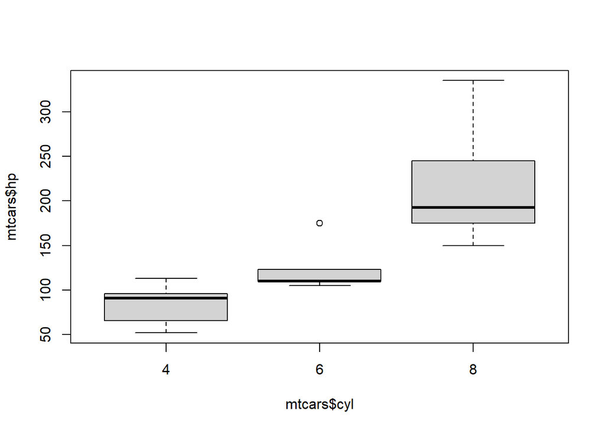

```r
mtcars$cyl<-factor(mtcars$cyl)
boxplot(mtcars$hp ~ mtcars$cyl)
```

# Prueba de Preprocesado

### La base de datos contiene 1.500 registros que representan a los clientes de un banco que demandaron un crédito personal en el año 2019. Este conjunto de datos contiene seis variables numéricas y cuatro variables categóricas además de la variable CLASE que muestra la información de si se ha devuelto o no el crédito solicitado. La descripción de la base de datos es la siguiente:

### Variables numéricas:

### NUM_FAMILIA: número de miembros de la unidad familiar.

### INVERSION: importe de la inversión.

### IMPCUOTA: importe de la cuota del préstamo.

### VALVIV: valor neto de las viviendas propias.

### INGRESOS: es la suma de los ingresos anuales fijos, los variables y otros ingresos provenientes de otras fuentes.

### SALDO: consta del saldo medio a la vista y el saldo medio no vista.

### Variables categóricas:

### CIVIL: estado civil de la persona que pide el préstamo: 1. Casado; 2. Separado; 3. Soltero.

### TIPO_TRABAJO: El tipo de trabajo se ha recodificado en las siguientes categorías: 1. Fijo; 2. Temporal; 3. Autónomo; 4. Pensionista; 5. Otros.

### VIVIENDA: modalidades de la vivienda: 1. Propiedad libre de cargas; 2. Propiedad hipotecada; 3. Alquiler; 4. Domicilio con la familia; 5. Otros.

### NACIONALIDAD: nacionalidad del que solicita el préstamo: 1. Español; 2. Extranjero.

### CLASE: Toma el valor SÍ, si se ha devuelto el crédito y NO, si no se ha devuelto.

### Se solicita que se realicen los siguientes análisis:

### 1.Análisis descriptivo de las variables.

### 2.Tablas de datos.

### 3.Análisis gráfico.

### 4.Tabla de correlaciones.

### 5.Imputación de datos ausentes.

### 6.Equilibrado de la muestra.

En primer lugar se carga la base de datos y se convierte en el dataframe “credito”.

```r
suppressWarnings(suppressPackageStartupMessages(library(readxl)))
credito <- read_excel("24685081-datos_preprocesado.xlsx",
     col_types = c("numeric", "numeric", "numeric",
         "numeric", "numeric", "numeric",
         "text", "text", "text", "text", "text"))
credito <- as.data.frame(credito, stringsAsFactors = FALSE)
```

Se convierten en factor las variables que son de clase carácter.

```r
for (columna in 1:11) {
  if(is.character(credito[,columna])){
    credito[,columna]<-as.factor(credito[,columna])
  }
}
```

Se asignan etiquetas a las variables tipo factor.

```r
#Variable CIVIL
estado_civil_levels<-c("1","2","3")
estado_civil_labels<-c("Casado","Separado","Soltero")
credito$CIVIL<-factor(credito$CIVIL,levels = estado_civil_levels,labels = estado_civil_labels)
#Variable TIPO_TRABAJO:
trabajo_levels<-c("1","2","3","4","5")
trabajo_labels<-c("Fijo","Temporal","Autónomo","Pensionista","Otros")
credito$TIPO_TRABAJO<-factor(credito$TIPO_TRABAJO,levels = trabajo_levels,labels = trabajo_labels)
#Variable VIVIENDA:
vivienda_levels<-c("1","2","3","4","5")
vivienda_labels<-c("Prop. libre","Prop. hipotecada","Alquiler","Domicilio con familia","Otros")
credito$VIVIENDA<-factor(credito$VIVIENDA,levels = vivienda_levels,labels = vivienda_labels)
#Variable NACIONALIDAD:
nacionalidad_levels<-c("1","2")
nacionalidad_labels<-c("Español","Extranjero")
credito$NACIONALIDAD<-factor(credito$NACIONALIDAD,levels = nacionalidad_levels,labels = nacionalidad_labels)
```

A continuación se realiza una exploración general de los datos del dataframe para detectar posibles datos ausentes (NA).

```r
sapply(credito,function(x) sum(is.na(x)))
```

```
##  NUM_FAMILIA    INVERSION     IMPCUOTA       VALVIV     INGRESOS        SALDO
##            9           21           17            0           32           21
##        CIVIL TIPO_TRABAJO     VIVIENDA NACIONALIDAD        CLASE
##            0            0            3            0            0
```

La muestra contiene varias variables con datos ausentes que deben ser tratados antes de continuar con el análisis descriptivo. No se va a eliminar ninguna variable del conjunto de datos puesto que la cantidad de datos ausentes es pequeño en comparación al tamaño de la muestra y la pérdida de información valiosa sería demasiado grande.

Para los datos ausentes en la variable no cuantitativa de tipo factor VIVIENDA se asigna el valor de la moda de la variable VIVIENDA a los valores ausentes. Se crea la función “moda” que calcula la moda y se aplica sobre la variable VIVIENDA.

```r
moda <- function(v){
  uniqv <- unique(v)
  uniqv[which.max(tabulate(match(v, uniqv)))]
}
moda(credito$VIVIENDA)
```

```
## [1] Prop. hipotecada
## 5 Levels: Prop. libre Prop. hipotecada Alquiler ... Otros
```

La moda de la variable VIVIENDA tiene el valor “Propiedad hipotecada”, que es el valor que se imputa a los datos ausentes en la variable VIVIENDA.

```r
credito[is.na(credito$VIVIENDA), "VIVIENDA"] <- moda(credito$VIVIENDA)
```

Se comprueba que ya no hay valores ausentes en la variable VIVIENDA.

```r
sapply(credito,function(x) sum(is.na(x)))
```

```
##  NUM_FAMILIA    INVERSION     IMPCUOTA       VALVIV     INGRESOS        SALDO
##            9           21           17            0           32           21
##        CIVIL TIPO_TRABAJO     VIVIENDA NACIONALIDAD        CLASE
##            0            0            0            0            0
```

Se asigna el valor de la media predictiva a las variables numéricas con datos ausentes.

```r
suppressWarnings(suppressPackageStartupMessages(library(mice)))
dataTemp<-mice(credito,m=5,method="pmm")
```

A continuación se agregan los datos obtenidos mediante el algoritmo mice al resto del conjunto de datos y le damos un nuevo nombre al conjunto de datos resultante: “credito_v1”

```r
credito_v1<-complete(dataTemp,1)
```

Se comprueba que ya no hay datos ausentes en la muestra.

```r
sapply(credito_v1,function(x) sum(is.na(x)))
```

```
##  NUM_FAMILIA    INVERSION     IMPCUOTA       VALVIV     INGRESOS        SALDO
##            0            0            0            0            0            0
##        CIVIL TIPO_TRABAJO     VIVIENDA NACIONALIDAD        CLASE
##            0            0            0            0            0
```

A continuación se procede a detectar visualmente si hay datos extremos (outliers) mediante los gráficos de caja.

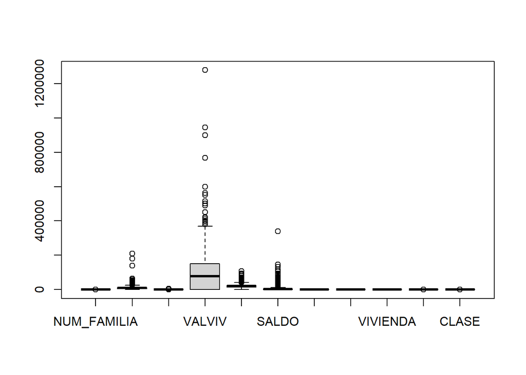

```
## [1] 737
```

```r
length(boxplot(credito_v1)$out)
```

Se detectan más de 700 outliers en el dataframe “credito_v1”. Se eliminan los outliers de las variables cuantitativas. Se ignoran los ouliers de las variables categóricas NACIONALIDAD y CLASE, especialmente esta última, ya que contiene información esencial que debe ser aprovechada (observaciones con valor “NO”.

```r
for(columna in 1:6) {
  credito_v1<-credito_v1[!credito_v1[,columna] %in% boxplot.stats(credito_v1[,columna])$out,]
}
```

Se comienza el análisis descriptivo de las variables con la base de datos preprocesada “credito_v1”

Estructura del archivo.

```r
str(credito_v1)
```

```
## 'data.frame':    1159 obs. of  11 variables:
##  $ NUM_FAMILIA : num  4 1 4 4 1 2 3 3 1 2 ...
##  $ INVERSION   : num  25480 5000 21000 7556 10000 ...
##  $ IMPCUOTA    : num  385.1 101.4 386.9 89.6 133.4 ...
##  $ VALVIV      : num  150253 60000 240000 150000 328467 ...
##  $ INGRESOS    : num  17706 12300 14500 12000 12583 ...
##  $ SALDO       : num  2358 1218 5662 1470 4564 ...
##  $ CIVIL       : Factor w/ 3 levels "Casado","Separado",..: 1 3 1 1 3 1 1 1 3 2 ...
##  $ TIPO_TRABAJO: Factor w/ 5 levels "Fijo","Temporal",..: 3 3 3 3 2 2 1 3 3 3 ...
##  $ VIVIENDA    : Factor w/ 5 levels "Prop. libre",..: 1 2 2 2 1 1 2 3 2 3 ...
##  $ NACIONALIDAD: Factor w/ 2 levels "Español","Extranjero": 1 2 1 1 1 1 1 1 1 1 ...
##  $ CLASE       : Factor w/ 2 levels "NO","SI": 2 2 2 2 2 2 2 2 2 1 ...
```

Información descriptiva de las variables.

```r
suppressWarnings(suppressPackageStartupMessages(library(skimr)))
skim(credito_v1)
```

Data summary

| Name | credito_v1 |
| --- | --- |
| Number of rows | 1159 |
| Number of columns | 11 |
| _______________________ |  |
| Column type frequency: |  |
| factor | 5 |
| numeric | 6 |
| ________________________ |  |
| Group variables | None |

**Variable type: factor**

| skim_variable | n_missing | complete_rate | ordered | n_unique | top_counts |
| --- | --- | --- | --- | --- | --- |
| CIVIL | 0 | 1 | FALSE | 3 | Cas: 571, Sol: 521, Sep: 67 |
| TIPO_TRABAJO | 0 | 1 | FALSE | 5 | Aut: 372, Fij: 257, Tem: 252, Pen: 160 |
| VIVIENDA | 0 | 1 | FALSE | 5 | Pro: 433, Pro: 275, Dom: 250, Alq: 151 |
| NACIONALIDAD | 0 | 1 | FALSE | 2 | Esp: 965, Ext: 194 |
| CLASE | 0 | 1 | FALSE | 2 | SI: 1035, NO: 124 |

**Variable type: numeric**

| skim_variable | n_missing | complete_rate | mean | sd | p0 | p25 | p50 | p75 | p100 | hist |
| --- | --- | --- | --- | --- | --- | --- | --- | --- | --- | --- |
| NUM_FAMILIA | 0 | 1 | 2.17 | 1.24 | 1.00 | 1.00 | 2.00 | 3.00 | 6.00 | ▇▂▂▁▁ |
| INVERSION | 0 | 1 | 7828.66 | 6094.46 | 285.10 | 2500.00 | 7000.00 | 10737.50 | 25500.00 | ▇▇▂▂▁ |
| IMPCUOTA | 0 | 1 | 167.54 | 99.50 | 8.78 | 83.33 | 162.21 | 250.00 | 495.03 | ▇▆▇▂▁ |
| VALVIV | 0 | 1 | 77652.45 | 83258.26 | 0.00 | 0.00 | 60000.00 | 130000.00 | 369000.00 | ▇▃▂▁▁ |
| INGRESOS | 0 | 1 | 16909.00 | 7714.13 | 0.00 | 12085.56 | 15962.24 | 21510.63 | 39646.00 | ▂▇▇▃▁ |
| SALDO | 0 | 1 | 1344.92 | 1890.94 | -920.13 | 4.02 | 508.89 | 1815.40 | 8579.40 | ▇▂▁▁▁ |

Primeras seis observaciones

```r
head(credito_v1)
```

```
##   NUM_FAMILIA INVERSION IMPCUOTA VALVIV INGRESOS   SALDO   CIVIL TIPO_TRABAJO
## 1           4  25480.00   385.08 150253 17705.93 2358.30  Casado     Autónomo
## 3           1   5000.00   101.38  60000 12300.00 1217.67 Soltero     Autónomo
## 4           4  21000.00   386.94 240000 14500.00 5662.40  Casado     Autónomo
## 5           4   7556.25    89.57 150000 12000.00 1469.73  Casado     Autónomo
## 6           1  10000.00   133.45 328467 12582.93 4563.52 Soltero     Temporal
## 7           2   8000.00   167.62 150000  8000.00  234.97  Casado     Temporal
##           VIVIENDA NACIONALIDAD CLASE
## 1      Prop. libre      Español    SI
## 3 Prop. hipotecada   Extranjero    SI
## 4 Prop. hipotecada      Español    SI
## 5 Prop. hipotecada      Español    SI
## 6      Prop. libre      Español    SI
## 7      Prop. libre      Español    SI
```

A continuación se emplean tablas para obtener información más específica. Se agrupan las variables CLASE y NUM_FAMILIA, y añadimos una columna con el porcentaje que representa el esfuerzo económico de la cuota sobre los ingresos.

```r
suppressWarnings(suppressPackageStartupMessages(library(tidyverse)))
credito_v1 %>%
  group_by(CLASE,NUM_FAMILIA) %>%
  summarise(ESFUERZO_ECON = (mean(IMPCUOTA) / (mean(INGRESOS)/12)*100))
```

```
## # A tibble: 12 x 3
## # Groups:   CLASE [2]
##    CLASE NUM_FAMILIA ESFUERZO_ECON
##    <fct>       <dbl>         <dbl>
##  1 NO              1         12.4
##  2 NO              2         11.4
##  3 NO              3         10.3
##  4 NO              4         11.8
##  5 NO              5         36.3
##  6 NO              6         10.2
##  7 SI              1         11.4
##  8 SI              2         12.6
##  9 SI              3         11.9
## 10 SI              4         11.6
## 11 SI              5         14.6
## 12 SI              6          5.35
```

Se agrupa la variable CIVIL a la tabla anterior

```r
credito_v1 %>%
  group_by(CLASE,NUM_FAMILIA,CIVIL) %>%
  summarise(ESFUERZO_ECON = (mean(IMPCUOTA) / (mean(INGRESOS)/12)*100))
```

```
## # A tibble: 28 x 4
## # Groups:   CLASE, NUM_FAMILIA [12]
##    CLASE NUM_FAMILIA CIVIL    ESFUERZO_ECON
##    <fct>       <dbl> <fct>            <dbl>
##  1 NO              1 Casado           25.3
##  2 NO              1 Separado          3.25
##  3 NO              1 Soltero          12.7
##  4 NO              2 Casado            9.28
##  5 NO              2 Separado          7.71
##  6 NO              2 Soltero          15.7
##  7 NO              3 Casado            9.93
##  8 NO              3 Separado         11.5
##  9 NO              3 Soltero          10.0
## 10 NO              4 Casado           13.8
## # ... with 18 more rows
```

Se aplica un filtro sobre los ingresos, para contemplar únicamente las observaciones de las familias que ingresan menos de 18000 euros anuales.

```r
credito_v1 %>%
  filter(INGRESOS<18000) %>%
  group_by(CLASE, NUM_FAMILIA,CIVIL) %>%
  summarise(ESFUERZO_ECON = (mean(IMPCUOTA) / (mean(INGRESOS)/12)*100))
```

```
## # A tibble: 27 x 4
## # Groups:   CLASE, NUM_FAMILIA [12]
##    CLASE NUM_FAMILIA CIVIL    ESFUERZO_ECON
##    <fct>       <dbl> <fct>            <dbl>
##  1 NO              1 Casado           25.3
##  2 NO              1 Soltero          14.1
##  3 NO              2 Casado           18.3
##  4 NO              2 Separado         10.1
##  5 NO              2 Soltero          15.7
##  6 NO              3 Casado           12.4
##  7 NO              3 Separado         13.8
##  8 NO              3 Soltero          12.1
##  9 NO              4 Casado           15.5
## 10 NO              4 Soltero           8.37
## # ... with 17 more rows
```

A continuación se aborda el análisis descriptivo gráfico.

Se ve las distribución de los valores de las variables numéricas de manera gráfica.

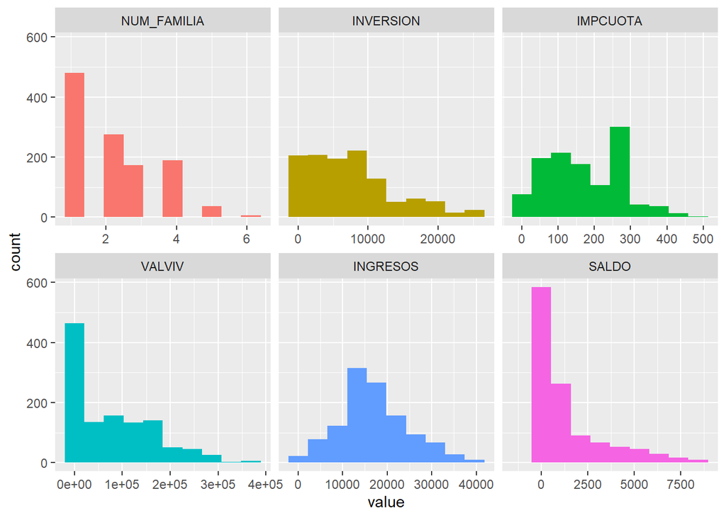

```r
suppressWarnings(suppressPackageStartupMessages(library(funModeling)))
plot_num(credito_v1)
```

También se visualizan las frecuencias de las variables categóricas.

```r
freq(credito_v1)
```

```
##      CIVIL frequency percentage cumulative_perc
## 1   Casado       571      49.27           49.27
## 2  Soltero       521      44.95           94.22
## 3 Separado        67       5.78          100.00
```

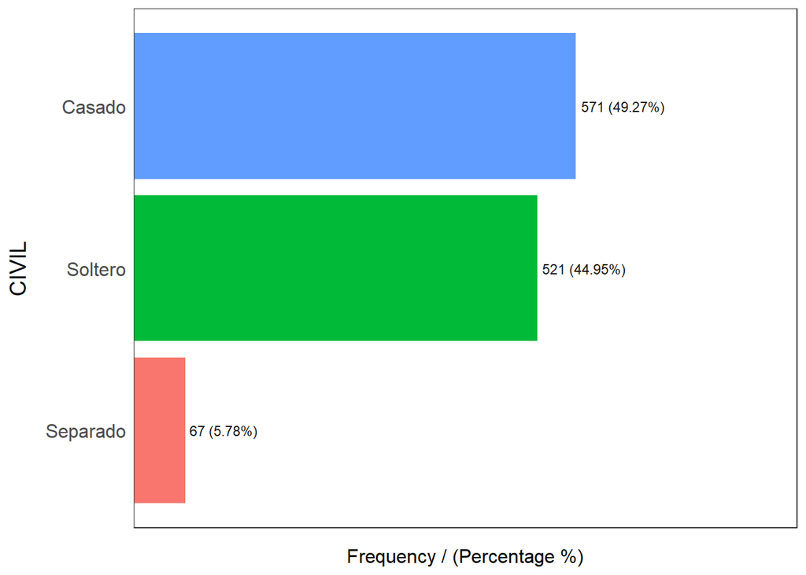

```
##   TIPO_TRABAJO frequency percentage cumulative_perc
## 1     Autónomo       372      32.10           32.10
## 2         Fijo       257      22.17           54.27
## 3     Temporal       252      21.74           76.01
## 4  Pensionista       160      13.81           89.82
## 5        Otros       118      10.18          100.00
```

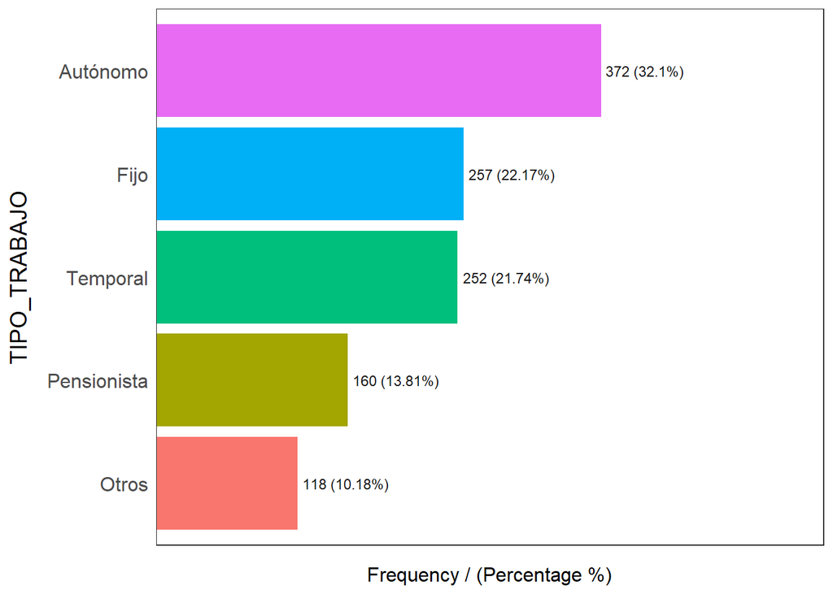

```
##                VIVIENDA frequency percentage cumulative_perc
## 1      Prop. hipotecada       433      37.36           37.36
## 2           Prop. libre       275      23.73           61.09
## 3 Domicilio con familia       250      21.57           82.66
## 4              Alquiler       151      13.03           95.69
## 5                 Otros        50       4.31          100.00
```

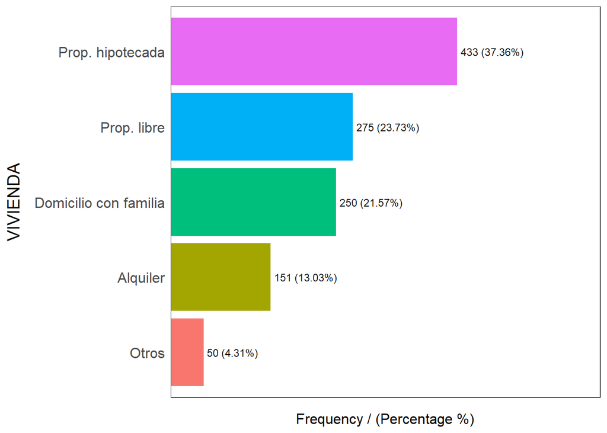

```
##   NACIONALIDAD frequency percentage cumulative_perc
## 1      Español       965      83.26           83.26
## 2   Extranjero       194      16.74          100.00
```

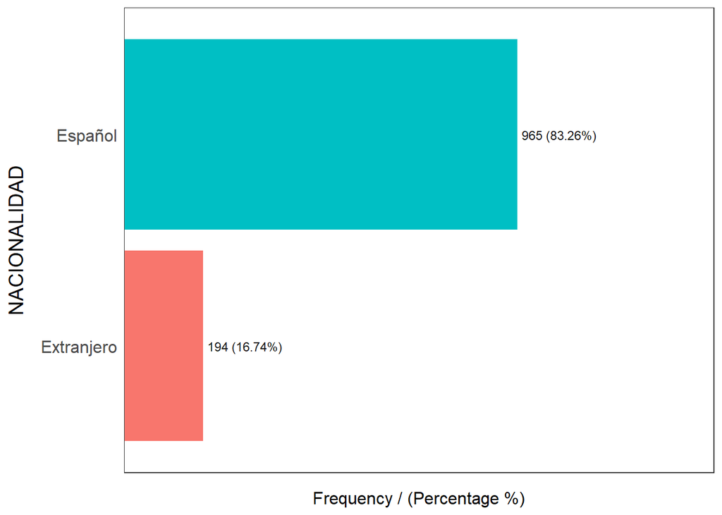

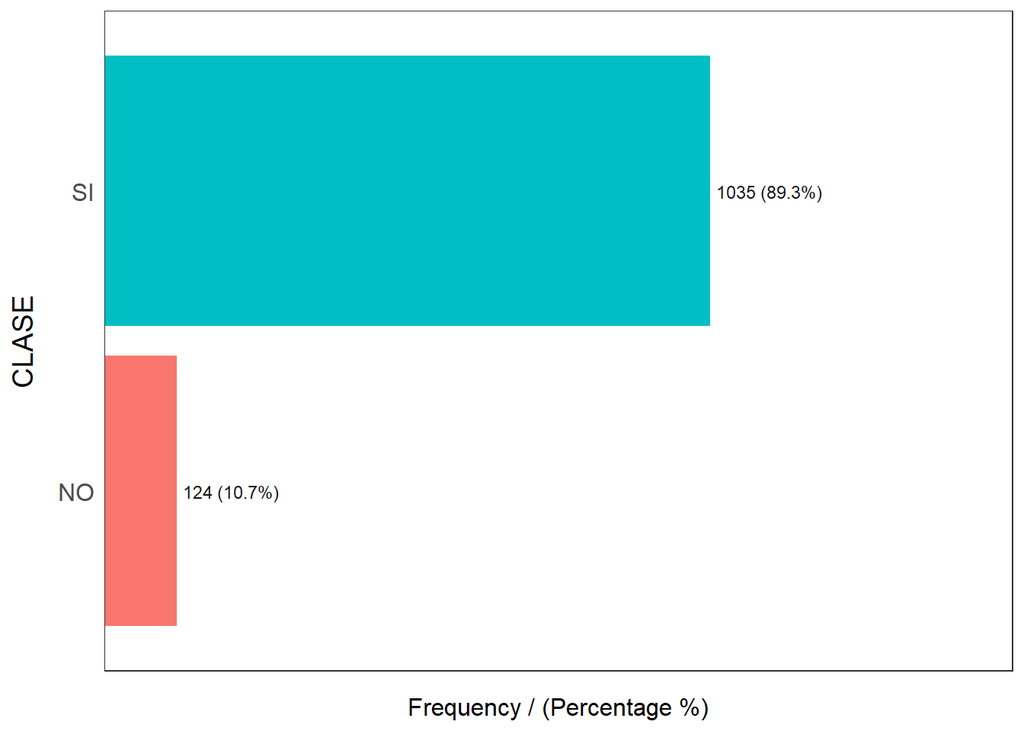

```
##   CLASE frequency percentage cumulative_perc
## 1    SI      1035       89.3            89.3
## 2    NO       124       10.7           100.0
```

```
## [1] "Variables processed: CIVIL, TIPO_TRABAJO, VIVIENDA, NACIONALIDAD, CLASE"
```

Se cruza la variable CLASE con la variable VIVIENDA

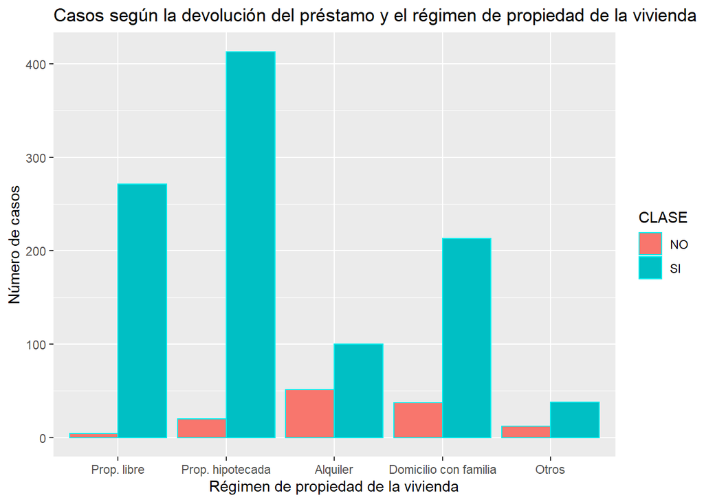

```r
gr2 <- ggplot(credito_v1, aes(VIVIENDA, fill = CLASE)) +
       geom_bar(position="dodge", colour="cyan2") +
       xlab("Régimen de propiedad de la vivienda") +
       ylab("Número de casos") +
       ggtitle("Casos según la devolución del préstamo y el régimen de propiedad de la vivienda")
gr2
```

Se realiza un grid con las variables CLASE y TIPO_TRABAJO

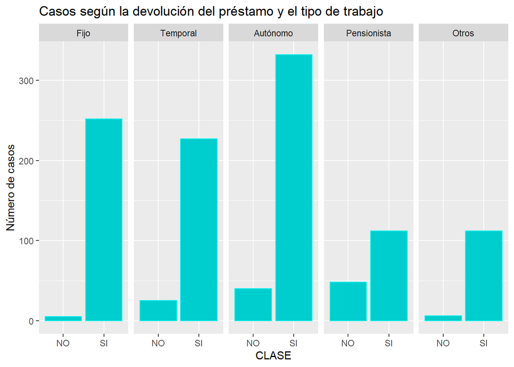

```r
gr3 <- ggplot(credito_v1, aes(x=CLASE),fill(CLASE)) +
       geom_bar(position="dodge",colour="cyan2", fill="cyan3") +
       ylab("Número de casos")
gr3 + facet_grid(.~ TIPO_TRABAJO) +
      ggtitle("Casos según la devolución del préstamo y el tipo de trabajo")
```

Se presenta un histograma con el número de registros de la devolución del crédito según los ingresos.

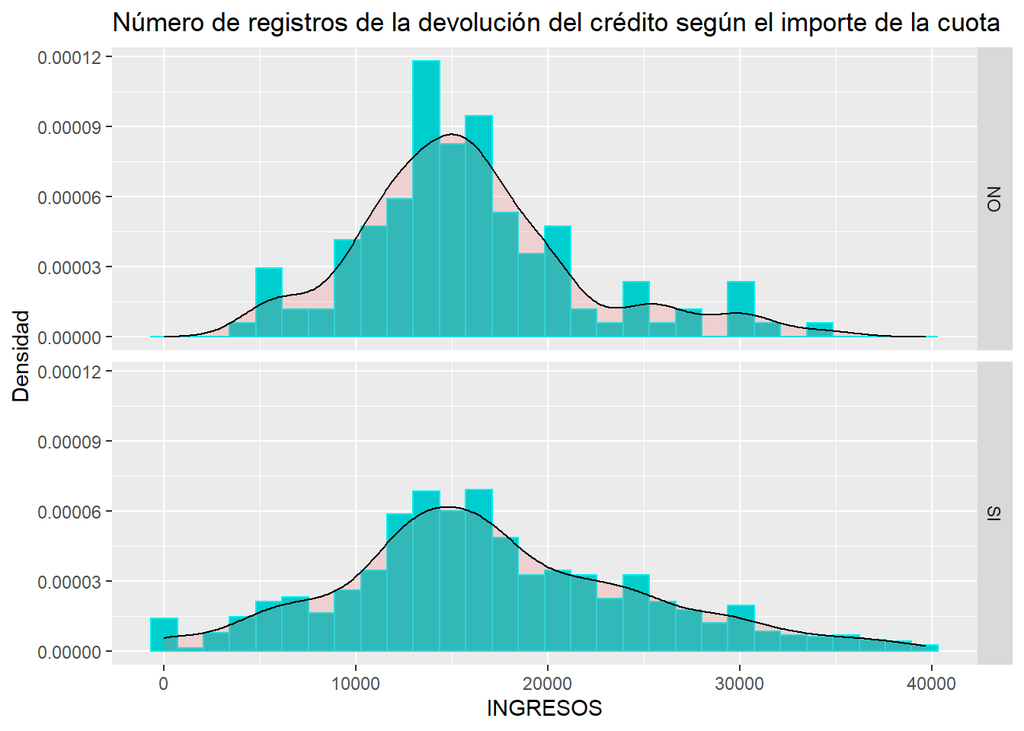

```r
hist1 <- ggplot(credito_v1, aes(x = INGRESOS)) +
         geom_histogram(aes(y=..density..), colour="cyan2", fill = "cyan3") +
         ylab("Densidad") +
         geom_density(alpha = .2, fill = "#FF6666") +
         ggtitle("Número de registros de la devolución del crédito según el importe de la cuota")
hist1 + facet_grid(CLASE ~.)
```

Se presentan diagramas de caja que relacionan NACIONALIDAD e IMPCUOTA.

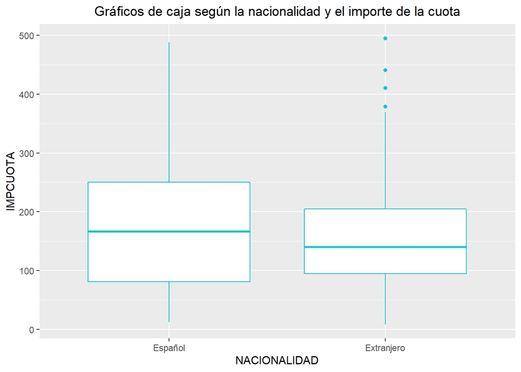

```r
plot1 <- ggplot(credito_v1, aes(x = NACIONALIDAD, y = IMPCUOTA )) +
     geom_boxplot(color= 'cyan3') +
     ggtitle("Gráficos de caja según la nacionalidad y el importe de la cuota") +
     theme(plot.title = element_text(hjust = 0.5))
plot1
```

Se realiza un Scatter plot con suavizado que relaciona la inversión y la cuota mensual.

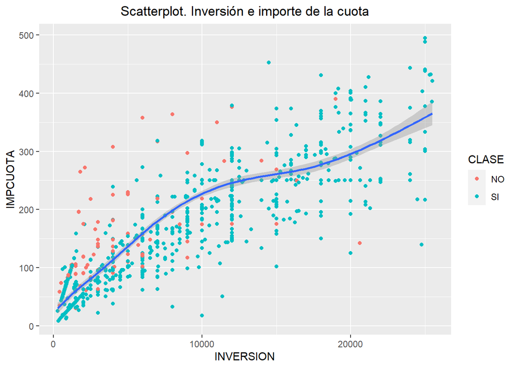

```r
ggplot(data = credito_v1, aes(INVERSION, IMPCUOTA)) +
  geom_point(aes(col = CLASE)) +
  stat_smooth() +
  ggtitle("Scatterplot. Inversión e importe de la cuota") +
  theme(plot.title = element_text(hjust = 0.5))
```

Correlaciones. Se genera el fichero “var_num” con las variables numéricas y sobre este archivo se calculan las correlaciones entre ellas.

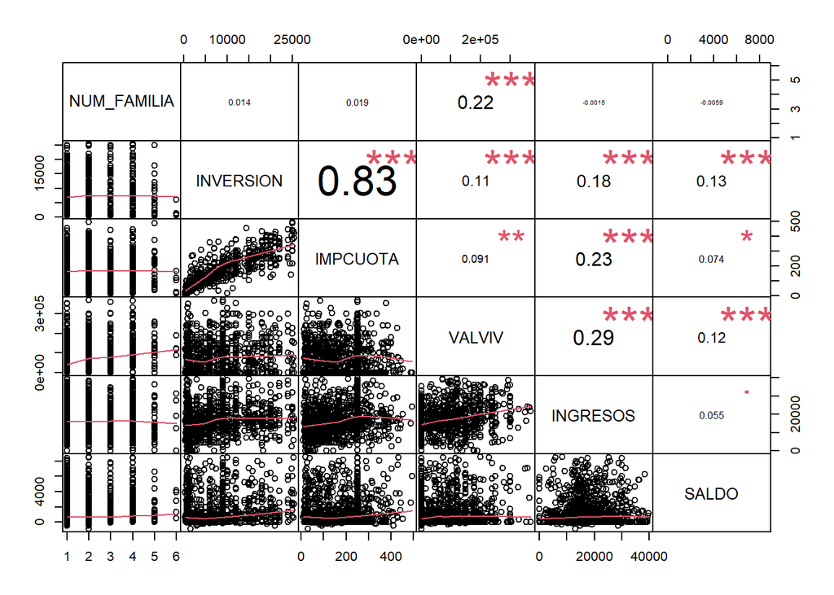

```r
var_num <- credito_v1[ ,c('NUM_FAMILIA', 'INVERSION', 'IMPCUOTA', 'VALVIV', 'INGRESOS', 'SALDO')]
suppressWarnings(suppressPackageStartupMessages(library(PerformanceAnalytics)))
chart.Correlation(var_num, histogram = F, pch = 19)
```

Equilibrado de la muestra. Se inspecciona la variable dependiente CLASE.

```r
skim(credito_v1$CLASE)
```

Data summary

| Name | credito_v1$CLASE |
| --- | --- |
| Number of rows | 1159 |
| Number of columns | 1 |
| _______________________ |  |
| Column type frequency: |  |
| factor | 1 |
| ________________________ |  |
| Group variables | None |

**Variable type: factor**

| skim_variable | n_missing | complete_rate | ordered | n_unique | top_counts |
| --- | --- | --- | --- | --- | --- |
| data | 0 | 1 | FALSE | 2 | SI: 1035, NO: 124 |

Se recuentan más de 1.000 casos en los que se ha devuelto el crédito y 124 casos en los que no. La diferencia es muy grande por lo que se hace necesario un equilibrado de la muestra. Se realiza un balanceo a nivel de datos. Se realiza un submuestreo de los datos con valor CLASE = SI mediante el método del cubo.

```r
# Data frame que contiene la población (CLASE = SI)
credito_v1_SI <- subset(credito_v1, CLASE == "SI")

# Creamos las variables indicadores para cada una de las variables de equilibrio
suppressWarnings(suppressPackageStartupMessages(library(sampling)))
X1 <- disjunctive(credito_v1_SI$CIVIL)
colnames(X1) <- levels(credito_v1_SI$CIVIL)

X2 <- disjunctive(credito_v1_SI$TIPO_TRABAJO)
colnames(X2) <- levels(credito_v1_SI$TIPO_TRABAJO)

X3 <- disjunctive(credito_v1_SI$VIVIENDA)
colnames(X3) <- levels(credito_v1_SI$VIVIENDA)

X4 <- disjunctive(credito_v1_SI$NACIONALIDAD)
colnames(X4) <- levels(credito_v1_SI$NACIONALIDAD)

# Creamos también una variable que vale 1 en todos los registros
# (para comprobar la estimación del tamaño poblacional)
UNO = rep(1, dim(credito_v1_SI)[1])

# Construimos la matriz de equilibrio a partir de estas variables
X <- cbind(UNO, X1, X2, X3, X4)

# Calculamos las probabilidades de inclusión.
# En este caso se trata de un m.a.s. con tamaño muestral de nB = 155
# Por lo tanto, la prob. de inclusión de cada individuo es 155/nA;
# donde nA es el tamaño de la población.
nB = 155
nA = nrow(credito_v1_SI)
pik = rep(nB/nA, nA)

# Selecionamos la muestra con la matriz de equilibrio X
#   Order=1; los datos son ordenados aleatoriamente
#   Order=2; se dejan como están
#   Order=3; se ordenan en orden decreciente
#   method=1; fase de aterrizaje mediante programación lineal
#   method=2; fase de aterrizaje mediante supresión de variables
s = samplecube(X, pik, order=1, comment = FALSE, method = 2)
muestra.SI = cbind(credito_v1_SI, s)
muestra.SI <- subset(muestra.SI, s == 1)
muestra.SI$s <- NULL

# Calidad de la muestra obtenida
Totales <- apply(X, 2, sum)
Horvitz.Thompson <- apply(X * s / pik, 2, sum)
calidad <- cbind.data.frame(Totales, Horvitz.Thompson)
calidad$Desv.Abs. <- round(calidad$Totales - calidad$Horvitz.Thompson, 2)
calidad$Desv.Rel. <- round((calidad$Totales / calidad$Horvitz.Thompson - 1) *100, 2)
print(as.matrix.data.frame(calidad))
```

```
##       Totales Horvitz.Thompson Desv.Abs. Desv.Rel.
##  [1,]    1035       1035.00000      0.00      0.00
##  [2,]     544        547.54839     -3.55     -0.65
##  [3,]      57         53.41935      3.58      6.70
##  [4,]     434        434.03226     -0.03     -0.01
##  [5,]     252        253.74194     -1.74     -0.69
##  [6,]     227        227.03226     -0.03     -0.01
##  [7,]     332        327.19355      4.81      1.47
##  [8,]     112        113.51613     -1.52     -1.34
##  [9,]     112        113.51613     -1.52     -1.34
## [10,]     271        273.77419     -2.77     -1.01
## [11,]     413        414.00000     -1.00     -0.24
## [12,]     100        100.16129     -0.16     -0.16
## [13,]     213        207.00000      6.00      2.90
## [14,]      38         40.06452     -2.06     -5.15
## [15,]     910        908.12903      1.87      0.21
## [16,]     125        126.87097     -1.87     -1.47
```

Mediante el algoritmo SMOTE aumentamos un 25% (de 124 a 155) el número de valores de CLASE “NO”.

```r
suppressWarnings(suppressPackageStartupMessages(library(DMwR)))
credito_v1_NO <- subset(credito_v1, CLASE == "NO")
# Debemos especificar el porcentaje de sobremuestreo. En este caso, el
# resultado será igual a: (155 / 124 -1) * 100 = 25%
p.over = 155 / dim(credito_v1_NO)[1] * 100 - 100
p.over
```

```
## [1] 25
```

```r
muestra.PROV<-rbind(muestra.SI,credito_v1_NO)
muestra.NO<-SMOTE( CLASE ~ ., muestra.PROV, perc.over = p.over, perc.under = 0 )
```

Se combinan la submuestra “muestra.SI” con la sobremuestra “muestra.NO”

```r
credito_v1.balanceado <- rbind( muestra.SI, muestra.NO )
```

Se revisa la tabla de frecuencias.

```r
table(credito_v1.balanceado$CLASE)
```

```
##
##  NO  SI
## 155 155
```

Se realiza la regresion sobre la variable dependiente binaria CLASE:

```r
#Se transforma la variable CLASE en numérica y se actualizan los valores para que tome los valores 0 para el valor "NO" y 1 para el valor "SI"
credito_v1.balanceado[,"CLASE"]<-as.numeric(credito_v1.balanceado[,"CLASE"])
credito_v1.balanceado$CLASE[credito_v1.balanceado$CLASE==1]<-0
credito_v1.balanceado$CLASE[credito_v1.balanceado$CLASE==2]<-1
#Se ejecuta el modelo de regresión que calcula la probabilidad de que una persona devuelva un crédito.
modelo <- glm(CLASE ~ ., data = credito_v1.balanceado, family = "binomial")
summary(modelo)
```

```
##
## Call:
## glm(formula = CLASE ~ ., family = "binomial", data = credito_v1.balanceado)
##
## Deviance Residuals:
##      Min        1Q    Median        3Q       Max
## -2.39797  -0.48917  -0.00969   0.42391   2.11424
##
## Coefficients:
##                                 Estimate Std. Error z value Pr(>|z|)
## (Intercept)                    6.573e+00  1.363e+00   4.822 1.42e-06 ***
## NUM_FAMILIA                   -3.928e-01  1.704e-01  -2.305 0.021159 *
## INVERSION                      3.447e-04  7.543e-05   4.570 4.87e-06 ***
## IMPCUOTA                      -1.395e-02  3.878e-03  -3.596 0.000323 ***
## VALVIV                         5.913e-06  4.172e-06   1.417 0.156433
## INGRESOS                      -1.045e-04  3.089e-05  -3.384 0.000714 ***
## SALDO                          7.190e-04  1.820e-04   3.950 7.83e-05 ***
## CIVILSeparado                 -1.523e+00  8.279e-01  -1.839 0.065846 .
## CIVILSoltero                  -2.139e+00  5.138e-01  -4.162 3.15e-05 ***
## TIPO_TRABAJOTemporal          -2.999e+00  7.425e-01  -4.040 5.35e-05 ***
## TIPO_TRABAJOAutónomo          -1.801e+00  6.456e-01  -2.789 0.005287 **
## TIPO_TRABAJOPensionista       -2.881e+00  7.392e-01  -3.898 9.70e-05 ***
## TIPO_TRABAJOOtros             -5.648e-01  9.012e-01  -0.627 0.530862
## VIVIENDAProp. hipotecada      -5.033e-01  6.520e-01  -0.772 0.440199
## VIVIENDAAlquiler              -1.618e+00  8.271e-01  -1.957 0.050393 .
## VIVIENDADomicilio con familia -7.880e-01  7.660e-01  -1.029 0.303562
## VIVIENDAOtros                 -1.675e+00  1.085e+00  -1.544 0.122670
## NACIONALIDADExtranjero        -1.662e+00  4.616e-01  -3.601 0.000317 ***
## ---
## Signif. codes:  0 '***' 0.001 '**' 0.01 '*' 0.05 '.' 0.1 ' ' 1
##
## (Dispersion parameter for binomial family taken to be 1)
##
##     Null deviance: 429.75  on 309  degrees of freedom
## Residual deviance: 207.79  on 292  degrees of freedom
## AIC: 243.79
##
## Number of Fisher Scoring iterations: 6
```

Las variables significativas al 95% de confianza son:

```r
summary(modelo)$coeff[-1,4] < 0.05
```

```
##                   NUM_FAMILIA                     INVERSION
##                          TRUE                          TRUE
##                      IMPCUOTA                        VALVIV
##                          TRUE                         FALSE
##                      INGRESOS                         SALDO
##                          TRUE                          TRUE
##                 CIVILSeparado                  CIVILSoltero
##                         FALSE                          TRUE
##          TIPO_TRABAJOTemporal          TIPO_TRABAJOAutónomo
##                          TRUE                          TRUE
##       TIPO_TRABAJOPensionista             TIPO_TRABAJOOtros
##                          TRUE                         FALSE
##      VIVIENDAProp. hipotecada              VIVIENDAAlquiler
##                         FALSE                         FALSE
## VIVIENDADomicilio con familia                 VIVIENDAOtros
##                         FALSE                         FALSE
##        NACIONALIDADExtranjero
##                          TRUE
```